# E18 and PN1 Harmony Integration

Irepan Salvador-Martinez

28/10/2021

# 1 About this analysis

Now that we have the supervised annotations from Gretel, I will integrate both libraries using Harmony.

```r
library(dplyr)
library(Seurat)
library(cowplot)
library(patchwork)
library(ggplot2)
library(BiocStyle)
library(harmony)
library(dittoSeq)
library(RColorBrewer)
```

# 2 Preprocess

## 2.1 Load pre-processed data

```r
Mo_E18_5_MesCells <-  readRDS("../3.1-Annotation/Mo_E18_5_MesCells_Annotated.rds")
dim(Mo_E18_5_MesCells)

Mo_PN1_MesCells <-  readRDS("../3.1-Annotation/Mo_PN1_MesCells_Annotated.rds")
dim(Mo_PN1_MesCells)
```

## 2.2 Merge datatsets

Before running Harmony, make a Seurat object and following the standard pipeline through PCA.

IMPORTANT DIFFERENCE: In the Seurat integration tutorial, you need to define a Seurat object for each dataset. With Harmony integration, create only one Seurat object with all cells.

```r
E18_PN1_Harmony <- merge(Mo_E18_5_MesCells, y =Mo_PN1_MesCells,
                         add.cell.ids = c("E18", "PN1"),
                         project = "E18_PN1_Harmony") %>%
  Seurat::NormalizeData(verbose = FALSE) %>%
  FindVariableFeatures(selection.method = "vst", nfeatures = 3000)

E18_PN1_Harmony <- ScaleData(E18_PN1_Harmony, verbose = FALSE,
                             features= rownames(E18_PN1_Harmony) ) %>%
  RunPCA(pc.genes = E18_PN1_Harmony@var.genes, npcs = 30, verbose = FALSE)
```

```r
rm(Mo_E18_5_MesCells, Mo_PN1_MesCells)
```

```r
options(repr.plot.height = 5, repr.plot.width = 12)
p1 <- DimPlot(object = E18_PN1_Harmony, reduction = "pca", pt.size = .1, group.by = "orig.ident")
p2 <- VlnPlot(object = E18_PN1_Harmony, features = "PC_1", group.by = "orig.ident", pt.size = 0)
plot_grid(p1,p2)
```

[output not shown]

# 3 Run Harmony

The simplest way to run Harmony is to pass the Seurat object and specify which variable(s) to integrate out. RunHarmony returns a Seurat object, updated with the corrected Harmony coordinates. Let’s set plot_convergence to TRUE, so we can make sure that the Harmony objective function gets better with each round.

```r
E18_PN1_Harmony <- E18_PN1_Harmony %>%
    RunHarmony("orig.ident", plot_convergence = TRUE)
```

[output not shown]

To directly access the new Harmony embeddings, use the Embeddings command.

```r
harmony_embeddings <- Embeddings(E18_PN1_Harmony, 'harmony')
harmony_embeddings[1:5, 1:5]
```

```r
E18_PN1_Harmony <- readRDS("E18_PN1_Harmony.rds")
```

Let’s make sure that the datasets are well integrated in the first 2 dimensions after Harmony.

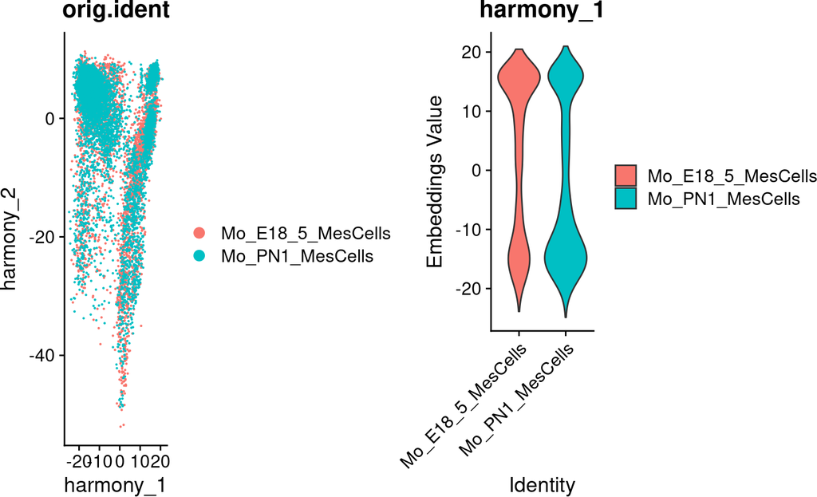

```r
p1 <- DimPlot(object = E18_PN1_Harmony, reduction = "harmony", pt.size = .1, group.by = "orig.ident")
p2 <- VlnPlot(object = E18_PN1_Harmony, features = "harmony_1", group.by = "orig.ident", pt.size = 0)
plot_grid(p1,p2)
```

# 4 Downstream analysis

## 4.1 FindNeighbours and UMAP

Many downstream analyses are performed on low dimensional embeddings, not gene expression. To use the corrected Harmony embeddings rather than PCs, set reduction = ‘harmony’. For example, let’s perform the UMAP and Nearest Neighbor analyses using the Harmony embeddings.

```r
E18_PN1_Harmony <- E18_PN1_Harmony %>%
    RunUMAP(reduction = "harmony", dims = 1:30) %>%
    FindNeighbors(reduction = "harmony", dims = 1:30) %>%
    FindClusters(resolution = 0.4) %>%
    identity()
```

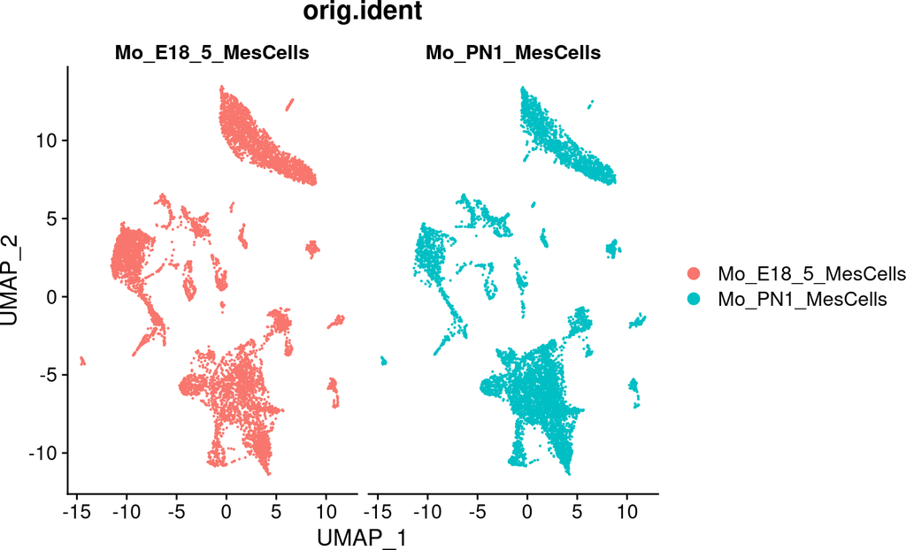

```r
DimPlot(E18_PN1_Harmony, reduction = "umap", group.by = "orig.ident", pt.size = .1, split.by = 'orig.ident')
```

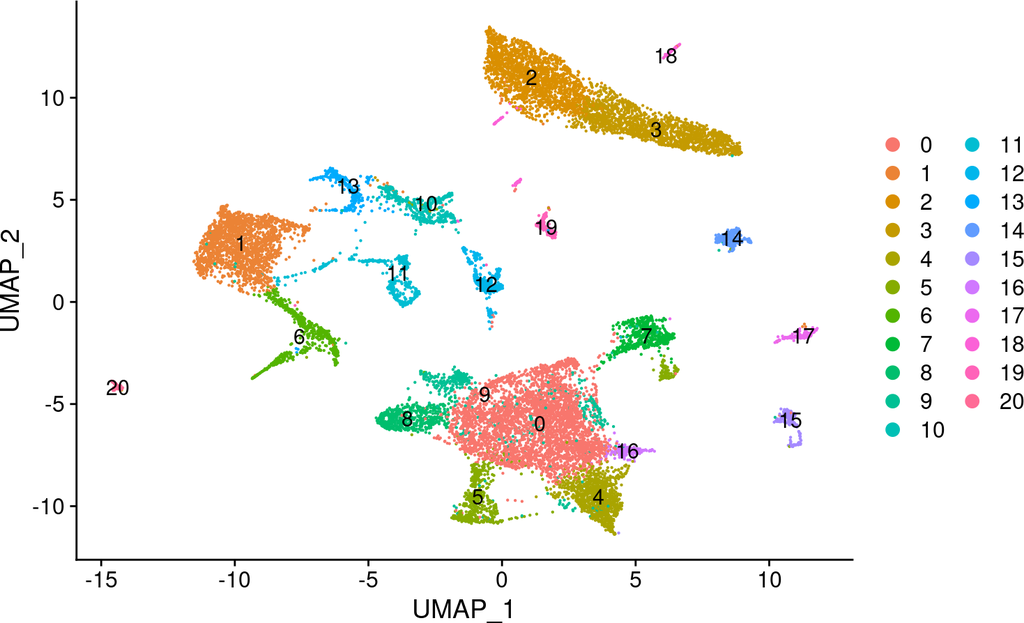

```r
DimPlot(E18_PN1_Harmony, reduction = "umap", label = TRUE, pt.size = .1)
```

# 5 Assign pre-defined color palette

```r
mylevels <- c("PaS/EndostealFibroblasts","Neutrophils1","Monocytes","Neutrophils2",
              "CAR","Osteoclasts","Chondrogenic","HPC","B_cell","OCP","Eo/Bas","PFP","PHP",
              "Myofibroblasts","Erythroid","Endothelial","Osteogenic","Schwann",
              "Tenogenic","CLP_NK_Tcells","doublets")

E18_PN1_Harmony@meta.data$Cell_Type <- factor(E18_PN1_Harmony@meta.data$Cell_Type, levels = mylevels)
```

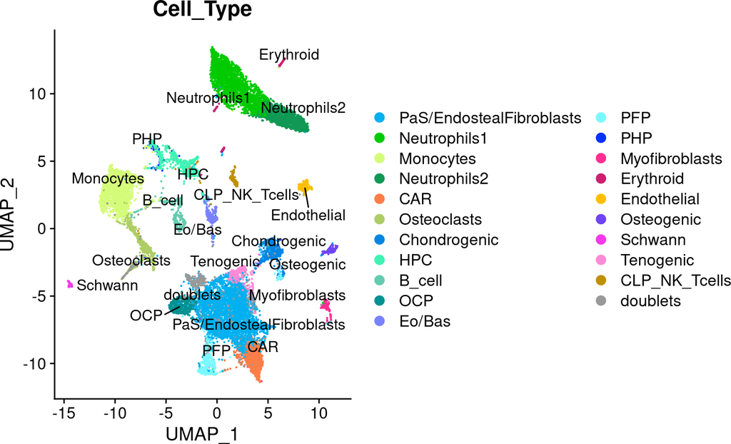

```r
col_palette <- c( rgb(0, 176/255, 240/255),       # C0=PaS/ Endosteal Fibroblasts (0, 176, 240)
                  rgb(1/255, 203/255,0),          # Neutrophils 1 (1, 203,0)
                  rgb(213/255, 252/255, 121/255), # Monocytes (213, 252,121)
                  rgb(16/255, 152/255, 85/255),   # Neutrophils2 (16, 152, 85)
                  rgb(255/255, 126/255, 72/255),  # CAR (255, 126, 72)
                  rgb(174/255, 205/255, 100/255), # Osteoclasts (174, 205, 100)
                  rgb(1/255, 134/255, 227/255),   # Chondrogenic Lineage (1, 134, 227)
                  rgb(62/255, 243/255, 180/255),  #C7=HPC (hematopoietic progenitor cells) (62, 243, 180)
                  rgb(101/255, 203/255, 176/255), #C8= B cell lineage (101, 203, 176)
                  rgb(0, 145/255, 147/255),       #C9=OCP (0, 145, 147)
                  rgb(122/255, 129/255, 255/255), #C10= Eo/Bas (122, 129, 255)
                  rgb(121/255, 249/255, 255/255), #C11= Proliferating Fibroblasts Progenitors (PFP) (121, 249, 255)
                  rgb(3/255, 50/255, 255/255),    #C12 = Proliferating Hematopoietic Progenitors (PHP) (3, 50, 255)
                  rgb(255/255, 47/255, 146/255),  #C13= Myofibroblasts (255, 47, 146)
                  rgb(205/255, 31/255, 113/255),  #C14= Erythroid cells (205, 31, 113)
                  rgb(255/255, 191/255, 0/255),   #C15= EC (endothelial cells) (255, 191, 0)
                  rgb(110/255, 68/255, 244/255),  #C16= Osteogenic lineage (110, 68, 244)
                  rgb(244/255, 56/255, 234/255),  #C17=Schwann cells(244, 56, 234)
                  rgb(254/255, 138/255, 216/255), #C18= Tenogenic lineage (254, 138, 216)
                  rgb(191/255,144/255, 0),        #C19= CLP NK&Tcell (191,144, 0)
                  rgb(0.6,0.6,0.6))

DimPlot(E18_PN1_Harmony, group.by = "Cell_Type", label = T, cols = col_palette, repel = T )
```

## 5.1 Visualise by library

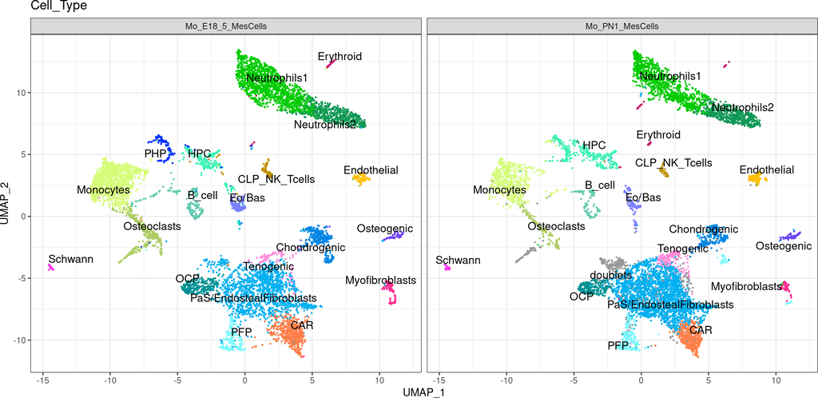

```r
DimPlot(E18_PN1_Harmony, group.by = "Cell_Type", split.by = "orig.ident", pt.size = 0.3,
        label = T, cols = col_palette, repel = T ) + theme_bw() + NoLegend()
```

## 5.2 Compositional plot

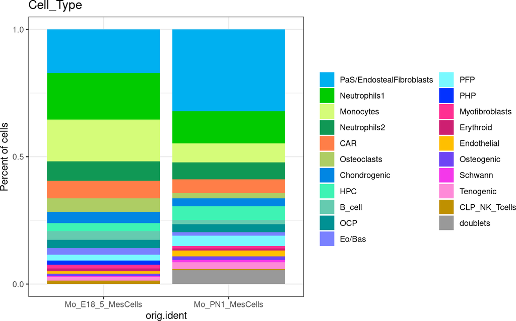

```r
db <- dittoBarPlot(object = E18_PN1_Harmony,
                   var = "Cell_Type",
                   group.by = "orig.ident",
                   retain.factor.levels = T,
                   color.panel =col_palette ) + theme_bw()
db
```

```r
write.csv(db$data, file = "E18_PN1_Harmony_CellType_composition.csv", row.names = FALSE)
```

```r
saveRDS(E18_PN1_Harmony, "E18_PN1_Harmony.rds")
```

# 6 Export RDS file for viz

```r
source(file = "../../utils/seurat2shiny.R")

seurat2shiny(E18_PN1_Harmony, reduction = "umap", save = TRUE, name = "E18_PN1_Harmony")
```